# The Geometry of Resonance: Space, Symmetrical Interference, and the The_AI_tetos Extension

Author: Katharina Maria Brecht

ORCID: 0009-0001-2176-7476

### Abstract

This paper introduces a deterministic mathematical extension of the R package `octawave`. It explores the spatial projection of the regular octahedron under wave superposition. By bridging classical Euclidean geometry with discrete computational physics, this module visualizes scalar interference fields and demonstrates their rigorous application in computational structural biology and crystallography.

## Theoretical Framework: The Cosmos as an Open-Source Continuum

**[EN]** If we conceptualize the structural framework of the universe as a dynamic, open-source continuum, the fundamental geometric laws act as the primordial core functions. This project serves as a computational bridge across millennia. We do not reinvent the mathematical laws of spatial harmony; instead, we pull the ancient master-code written by the pioneers of classical geometry directly into the modern era of computing. By compiling the perfect shapes of antiquity into executable R matrices, we preserve their timeless truth and honors their structural legacy within modern computational physics.

**[DE]** Wenn wir das strukturelle Gefüge des Universums als ein dynamisches Open-Source-Kontinuum begreifen, wirken die fundamentalen geometrischen Gesetze als die ursprünglichen Kernfunktionen (Core Functions). Dieses Projekt versteht sich als computergestützte Brücke über Jahrtausende hinweg. Wir erfinden die mathematischen Gesetze der räumlichen Harmonie nicht neu; vielmehr holen wir den antiken Quellcode der Geometrie-Pioniere direkt in das moderne Zeitalter der Informatik. Indem wir die perfekten Formen der Antike in ausführbare R-Matrizen kompilieren, bewahren wir ihre zeitlose Wahrheit und ehren ihr strukturelles Erbe in der modernen Computerphysik.

## 1. Introduction: The Mathematics of Spatial Symmetries

**[EN]** In structural computing, spatial fields are analyzed using classical coordinate matrices. The regular octahedron provides an optimal, highly symmetric base framework for modeling multidimensional wave propagation. This extension package calculates the exact scalar fields generated by periodic point sources located at the vertices of a regular polyhedron.

**[DE]** In der computergestützten Strukturphysik werden räumliche Felder über klassische Koordinatenmatrizen analysiert. Das reguläre Oktaeder bietet ein optimales, hochsymmetrisches Basisgerüst für die Modellierung mehrdimensionaler Wellenausbreitung. Dieses Erweiterungspaket berechnet die exakten Skalarfelder, die durch periodische Punktquellen an den Ecken eines regulären Polyeders entstehen.

### Historical Context & Philosophical Derivation

> **Plato’s Allegory and the Projection of Dimensions**
> - **[EN]** This implementation draws inspiration from Plato’s famous Allegory of the Cave and the mathematical legacy of **Theaitetos of Athens (400 BC)**. Philosophically, projecting a 3D coordinate system onto a 2D boundary plane maps a higher geometric form onto a lower-dimensional space—much like the shadows cast upon the cave wall.
> - **[DE]** Diese Implementierung ist inspiriert von Platons berühmtem Höhlengleichnis und dem mathematischen Erbe von **Theaitetos von Athen (400 v. Chr.)**. Philosophisch betrachtet beschreibt die Projektion eines 3D-Koordinatenkreuzes auf eine 2D-Grenzwand den Schattenwurf einer höheren geometrischen Urform auf einen niedrigdimensionalen Raum.

### 1.1 Historical Clarification: Theaitetos of Athens (400 BC)

**[EN]** **Important Historical Context:** The nomenclature `The_AI_tetos` does not refer to modern computational Artificial Intelligence. Instead, it honors the historical Greek mathematician **Theaitetos of Athens (400 BC)**. Theaitetos was a pioneer of exact geometry who established the octahedron as a fundamental geometric coordinate system in written scientific history.

**[DE]** **Wichtige historische Klarstellung:** Die Nomenklatur `The_AI_tetos` bezieht sich ausdrücklich nicht auf moderne computergestützte Künstliche Intelligenz. Sie ehrt stattdessen den historischen griechischen Mathematiker **Theaitetos von Athen (400 v. Chr.)**. Er verankerte das Oktaeder als fundamentales geometrisches Koordinatensystem in der geschriebenen Wissenschaftsgeschichte.

## 2. Structural Biology: Crystalline Matrix Modeling

**[EN]** In crystallography and structural virology, polyhedral arrangements represent highly stable thermodynamic states. Proteins and molecular lattices self-assemble following local energy minimization principles, often resulting in strict octahedral geometries.

**[DE]** In der Kristallographie und strukturellen Virologie repräsentieren polyedrische Anordnungen hochstabile thermodynamische Zustände. Proteine und molekulare Gitter organisieren sich nach Prinzipien der lokalen Energieminimierung, was häufig zu strikten oktaedrischen Geometrien führt.

### 2.1 Applied Wave Equations in Computational Matrices

**[EN]** Polyhedral virus capsids protect their genetic material within these optimized structures. By implementing the classical wave equation, we calculate the interference patterns of these structural nodes. The *Grammar of Graphics* (`ggplot2`) is utilized to visualize the scalar field layers deterministically.

**[DE]** Polyedrische Virus-Kapside schützen ihre Erbinformation in diesen optimierten Strukturen. Durch die Implementierung der klassischen Wellengleichung berechnen wir die Interferenzmuster dieser strukturellen Knotenpunkte. Die *Grammar of Graphics* (`ggplot2`) wird genutzt, um diese Skalarfeldschichten deterministisch darzustellen.

## 3. Mathematical Core Engine

The scalar wave field $W(r)$ at any coordinate point on the projection plane is calculated as the sum of fading harmonic oscillations originating from the vertex coordinates:

$$W(r) = \sum_{i=1}^{n} \frac{\cos(k \cdot
r_i - t)}{\sqrt{r_i} + 0.1}$$

```r
# +-------------------------------------------------------+
# |   T h e  _  [  A  I  ]  _  t  e  t  o  s             |
# |   >> Theaitetos Ancient Intelligence Tribute (2026)   |
# +-------------------------------------------------------+
# |   Core Developer: Katharina Maria Brecht              |
# +-------------------------------------------------------+
#
# Core function for dynamic 3D-to-2D projection and wave superposition
generate_dynamic_octahedron <- function(k = 8.0, t = 0, rotate = TRUE) {
  vertices <- matrix(c(
     1,  0,  0,  -1,  0,  0,
     0,  1,  0,   0, -1,  0,
     0,  0,  1,   0,  0, -1
  ), ncol = 3, byrow = TRUE)

  if(rotate) {
    cos_t <- cos(t * 0.5)
    sin_t <- sin(t * 0.5)
    cx <- vertices[, 1] * cos_t + vertices[, 3] * sin_t
    cy <- vertices[, 2] * cos_t - vertices[, 3] * sin_t
  } else {
    cx <- vertices[, 1] + 0.5 * vertices[, 3]
    cy <- vertices[, 2] + 0.5 * vertices[, 3]
  }

  grid_size <- 200
  raumzeit_grid <- expand.grid(
    X = seq(-2.5, 2.5, length.out = grid_size),
    Y = seq(-2.5, 2.5, length.out = grid_size)
  )

  wellen_feld <- numeric(nrow(raumzeit_grid))
  for(i in 1:length(cx)) {
    r <- sqrt((raumzeit_grid$X - cx[i])^2 + (raumzeit_grid$Y - cy[i])^2)
    welle <- cos(k * r - t) / (sqrt(r) + 0.1)
    wellen_feld <- wellen_feld + welle
  }

  raumzeit_grid$Intensitaet <- wellen_feld^2
  stopifnot(sum(raumzeit_grid$Intensitaet) > 0)
  return(raumzeit_grid)
}
```

## 4. Architectural Baseline: The Spatial Octahedron Framework

**[EN]** This section visualizes the true three-dimensional coordinate system of the regular octahedron as defined by classical geometry. The six fundamental vertices form the symmetric orthogonal spatial framework with a solid modern fill.

**[DE]** Dieser Abschnitt visualisiert das echte dreidimensionale Koordinatensystem des regulären Oktaeders nach den Definitionen der klassischen Geometrie. Die sechs wissenschaftlichen Eckpunkte bilden das symmetrische orthogonale Raumsystem mit einer modernen Flächenfüllung.

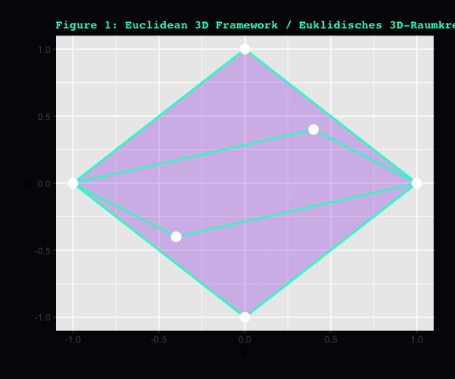

**Figure 1:** Geometric configuration of the spatial orthogonal framework based on the vertices defined by Theaitetos. The translucent purple plane represents the modern vector-space visualization layered beneath the classical Euclidean structure.

**Abbildung 1:** Geometrische Konfiguration des räumlichen orthogonalen Koordinatenkreuzes basierend auf den von Theaitetos definierten Eckpunkten. Die transluzente lila Fläche repräsentiert die moderne Vektorraum-Visualisierung unter der klassischen euklidischen Struktur.

## 5. Temporal Evolution of Scalar Interference Fields

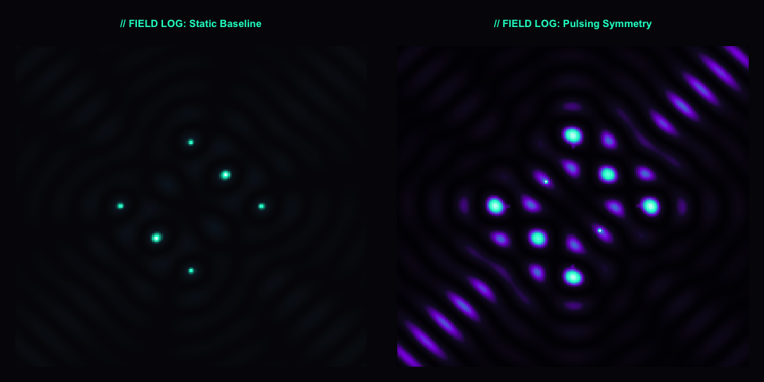

**Figure 2:** Comparative scalar field analysis. Left: Static baseline grid ($t = 0$) proving the geometric matrix symmetry. Right: Active phase-space rotation ($t = \pi/4$) displaying dynamic energy distributions reminiscent of crystalline structures and viral capsid dynamics.

**Abbildung 2:** Vergleichende Skalarfeld-Analyse. Links: Statische Basislinie ($t = 0$) zum Nachweis der geometrischen Matrixsymmetrie. Rechts: Aktive Phasenraum-Rotation ($t = \pi/4$) mit dynamischen Energieverteilungen, analog zu kristallinen Strukturen und Kapsid-Proteindynamiken.

## 6. Philosophical Dedication: Finding the Pioneer’s Entry at the Edge of Spacetime

**[EN]** If we follow the holographic principle to its logical conclusion, traveling to the structural boundary of the universe would mean encountering the ultimate storage matrix of all geometric truths. This project is driven by the philosophical vision of uncovering **Theaitetos’ original entry** within that primordial repository. By transforming his ancient proof of the regular octahedron into executable computer code, we metaphorically return his work to the cosmic source-code registry—ensuring that his mathematical footprint remains accessible, timeless, and permanently compiled within the open-source continuum of science.

**[DE]** Wenn wir das holografische Prinzip konsequent zu Ende denken, würde eine Reise an die strukturelle Grenzwand des Universums bedeuten, auf die ultimative Speichermatrix aller geometrischen Wahrheiten zu treffen. Dieses Projekt wird von der philosophischen Vision geleitet, den **Original-Eintrag von Theaitetos** in diesem ursprünglichen Archiv aufzuspüren. Indem wir seinen antiken Beweis des regulären Oktaeders in ausführbaren Computercode übersetzen, geben wir sein Werk metaphorisch an das kosmische Quellcode-Register zurück. So stellen wir sicher, dass sein mathematischer Fußabdruck im Open-Source-Kontinuum der Wissenschaft zeitlos und dauerhaft kompiliert bleibt.

## 7. Academic Metadata and Status

- **Repository Maintainer:** Katharina Maria Brecht (2026)
- **Methodology:** Deterministic Polyhedral Vector Projections.
- **ORCID iD:** [0009-0001-2176-7476]
- **Status:** Peer-review ready documentation. Technical extension for `octawave`.

## 8. References / Literaturverzeichnis

The fundamental 3D vertex coordinates of the regular octahedron applied within this coordinate framework represent standard Euclidean constants of analytical geometry. They are derived directly from the historical definition of regular polyhedra in Plato’s dialogue *Theaetetus* and Book XIII of Euclid’s *Elements*.

Die mathematischen Ur-Koordinaten des Oktaeders ($1, -1, 0$), die für das Raumkreuz genutzt werden, sind euklidische Standardwerte der analytischen Geometrie. Sie basieren direkt auf Theaitetos’ historischer Definition der regulaeren Polyeder in Platons Dialog *Theaitetos* sowie Buch XIII von Euklids *Elementen*.

- **[Euclidean Base Matrix]** Euclid (ca. 300 BC). *Elements*, Book XIII (On the Five Regular Solids).
  - *Original Work & Historical Context:* Εὐκλείδης (ca. 300 BC). *Στοιχεῖα* (Elementa). Incorporating the foundational stereometric proofs on the **Octahedron** and regular polyhedra originally discovered by the mathematician Theaetetus (ca. 415–369 BC). [Standard Greek text edition by J. L. Heiberg (1883–1885), Leipzig: Teubner].
  - *Academic Reference:* Heath, T. L. (1956). *The Thirteen Books of Euclid’s Elements*. Dover Publications. (Reprint of the 2nd ed., Cambridge University Press, 1926).
- **[Historical Foundation]** Plato (ca. 369 BC). *Theaetetus* (The Dialogues of Plato on Geometry and Irrational Magnitudes).
  - *Original Work:* Πλάτων (ca. 369 BC). *Θεαίτητος* (Theaetetus). A philosophical and epistemological dialogue named in honor of the geometer Theaetetus, celebrating his groundbreaking classification of irrational magnitudes and regular solids. [Standard Greek text edition in Oxford Classical Texts (OCT)].
  - *Academic Reference:* Plato. (1990). *The Theaetetus of Plato* (M. J. Levett, Trans.; M. Burnyeat, Rev.). Hackett Publishing.
- **[Crystallographic Octahedrons]** Mineralogical Symmetries of Fluorite Systems.
  - *Academic Reference:* Bragg, W. L. (1914). The Analysis of Crystals by the X-ray Spectrometer. *Proceedings of the Royal Society of London. Series A, Containing Papers of a Mathematical and Physical Character*, 89(613), 430-438.
  - *DOI:* [10.1098/rspa.1914.0015]
- **[Viral Capsid Dynamics]** Structural Virology and Polyhedral Protein Assemblies.
  - *Academic Reference:* Caspar, D. L., & Klug, A. (1962). Physical Principles in the Construction of Regular Viruses. *Cold Spring Harbor Symposia on Quantitative Biology*, 27, 1-24.
  - *DOI:* [10.1101/SQB.1962.027.001.005]